# Risk Factor Analysis

## Outcome Variable

**Outcome Variable:** stunted

## Predictor Variables

**Intervention Variable:** enwast

**Adjustment Set:**

- arm
- sex
- W_mage
- meducyrs
- feducyrs
- vagbrth
- single
- brthmon
- W_parity
- delta_W_mage
- delta_meducyrs
- delta_feducyrs
- delta_vagbrth
- delta_single
- delta_brthmon
- delta_W_parity

## Stratifying Variables

The analysis was stratified on these variable(s):

- agecat
- studyid
- country

## Data Summary

| agecat | studyid | country | enwast | stunted | n_cell | n |
| --- | --- | --- | --- | --- | --- | --- |
| Birth | ki0047075b-MAL-ED | BANGLADESH | 0 | 0 | 174 | 241 |
| Birth | ki0047075b-MAL-ED | BANGLADESH | 0 | 1 | 27 | 241 |
| Birth | ki0047075b-MAL-ED | BANGLADESH | 1 | 0 | 36 | 241 |
| Birth | ki0047075b-MAL-ED | BANGLADESH | 1 | 1 | 4 | 241 |
| Birth | ki0047075b-MAL-ED | BRAZIL | 0 | 0 | 163 | 183 |
| Birth | ki0047075b-MAL-ED | BRAZIL | 0 | 1 | 14 | 183 |
| Birth | ki0047075b-MAL-ED | BRAZIL | 1 | 0 | 6 | 183 |
| Birth | ki0047075b-MAL-ED | BRAZIL | 1 | 1 | 0 | 183 |
| Birth | ki0047075b-MAL-ED | INDIA | 0 | 0 | 146 | 203 |
| Birth | ki0047075b-MAL-ED | INDIA | 0 | 1 | 24 | 203 |
| Birth | ki0047075b-MAL-ED | INDIA | 1 | 0 | 27 | 203 |
| Birth | ki0047075b-MAL-ED | INDIA | 1 | 1 | 6 | 203 |
| Birth | ki0047075b-MAL-ED | NEPAL | 0 | 0 | 136 | 169 |
| Birth | ki0047075b-MAL-ED | NEPAL | 0 | 1 | 12 | 169 |
| Birth | ki0047075b-MAL-ED | NEPAL | 1 | 0 | 19 | 169 |
| Birth | ki0047075b-MAL-ED | NEPAL | 1 | 1 | 2 | 169 |
| Birth | ki0047075b-MAL-ED | PERU | 0 | 0 | 248 | 279 |
| Birth | ki0047075b-MAL-ED | PERU | 0 | 1 | 25 | 279 |
| Birth | ki0047075b-MAL-ED | PERU | 1 | 0 | 5 | 279 |
| Birth | ki0047075b-MAL-ED | PERU | 1 | 1 | 1 | 279 |
| Birth | ki0047075b-MAL-ED | SOUTH AFRICA | 0 | 0 | 218 | 260 |
| Birth | ki0047075b-MAL-ED | SOUTH AFRICA | 0 | 1 | 22 | 260 |
| Birth | ki0047075b-MAL-ED | SOUTH AFRICA | 1 | 0 | 16 | 260 |
| Birth | ki0047075b-MAL-ED | SOUTH AFRICA | 1 | 1 | 4 | 260 |
| Birth | ki0047075b-MAL-ED | TANZANIA, UNITED REPUBLIC OF | 0 | 0 | 104 | 118 |
| Birth | ki0047075b-MAL-ED | TANZANIA, UNITED REPUBLIC OF | 0 | 1 | 12 | 118 |
| Birth | ki0047075b-MAL-ED | TANZANIA, UNITED REPUBLIC OF | 1 | 0 | 1 | 118 |
| Birth | ki0047075b-MAL-ED | TANZANIA, UNITED REPUBLIC OF | 1 | 1 | 1 | 118 |
| Birth | ki1000108-CMC-V-BCS-2002 | INDIA | 0 | 0 | 65 | 85 |
| Birth | ki1000108-CMC-V-BCS-2002 | INDIA | 0 | 1 | 9 | 85 |

[output cut: 314 more lines]

The following strata were considered:

- agecat: 24 months, studyid: ki0047075b-MAL-ED, country: BANGLADESH
- agecat: 24 months, studyid: ki0047075b-MAL-ED, country: BRAZIL
- agecat: 24 months, studyid: ki0047075b-MAL-ED, country: INDIA
- agecat: 24 months, studyid: ki0047075b-MAL-ED, country: NEPAL
- agecat: 24 months, studyid: ki0047075b-MAL-ED, country: PERU
- agecat: 24 months, studyid: ki0047075b-MAL-ED, country: SOUTH AFRICA
- agecat: 24 months, studyid: ki0047075b-MAL-ED, country: TANZANIA, UNITED REPUBLIC OF
- agecat: 24 months, studyid: ki1000108-CMC-V-BCS-2002, country: INDIA
- agecat: 24 months, studyid: ki1000108-IRC, country: INDIA
- agecat: 24 months, studyid: ki1017093-NIH-Birth, country: BANGLADESH
- agecat: 24 months, studyid: ki1017093b-PROVIDE, country: BANGLADESH
- agecat: 24 months, studyid: ki1017093c-NIH-Crypto, country: BANGLADESH
- agecat: 24 months, studyid: ki1066203-TanzaniaChild2, country: TANZANIA, UNITED REPUBLIC OF
- agecat: 24 months, studyid: ki1101329-Keneba, country: GAMBIA
- agecat: 24 months, studyid: ki1113344-GMS-Nepal, country: NEPAL
- agecat: 24 months, studyid: ki1114097-CMIN, country: BANGLADESH
- agecat: 24 months, studyid: ki1114097-CMIN, country: GUINEA-BISSAU
- agecat: 24 months, studyid: ki1114097-CMIN, country: PERU
- agecat: 24 months, studyid: ki1114097-CONTENT, country: PERU
- agecat: 24 months, studyid: ki1119695-PROBIT, country: BELARUS
- agecat: 24 months, studyid: ki1126311-ZVITAMBO, country: ZIMBABWE
- agecat: 24 months, studyid: ki1135781-COHORTS, country: GUATEMALA
- agecat: 24 months, studyid: ki1135781-COHORTS, country: INDIA
- agecat: 24 months, studyid: ki1135781-COHORTS, country: PHILIPPINES
- agecat: 24 months, studyid: ki1148112-LCNI-5, country: MALAWI
- agecat: 24 months, studyid: kiGH5241-JiVitA-3, country: BANGLADESH
- agecat: 24 months, studyid: kiGH5241-JiVitA-4, country: BANGLADESH
- agecat: 6 months, studyid: ki0047075b-MAL-ED, country: BANGLADESH
- agecat: 6 months, studyid: ki0047075b-MAL-ED, country: BRAZIL
- agecat: 6 months, studyid: ki0047075b-MAL-ED, country: INDIA
- agecat: 6 months, studyid: ki0047075b-MAL-ED, country: NEPAL
- agecat: 6 months, studyid: ki0047075b-MAL-ED, country: PERU
- agecat: 6 months, studyid: ki0047075b-MAL-ED, country: SOUTH AFRICA
- agecat: 6 months, studyid: ki0047075b-MAL-ED, country: TANZANIA, UNITED REPUBLIC OF
- agecat: 6 months, studyid: ki1000108-CMC-V-BCS-2002, country: INDIA
- agecat: 6 months, studyid: ki1000108-IRC, country: INDIA
- agecat: 6 months, studyid: ki1000109-EE, country: PAKISTAN
- agecat: 6 months, studyid: ki1000109-ResPak, country: PAKISTAN
- agecat: 6 months, studyid: ki1000304b-SAS-CompFeed, country: INDIA
- agecat: 6 months, studyid: ki1000304b-SAS-FoodSuppl, country: INDIA
- agecat: 6 months, studyid: ki1017093-NIH-Birth, country: BANGLADESH
- agecat: 6 months, studyid: ki1017093b-PROVIDE, country: BANGLADESH
- agecat: 6 months, studyid: ki1017093c-NIH-Crypto, country: BANGLADESH
- agecat: 6 months, studyid: ki1066203-TanzaniaChild2, country: TANZANIA, UNITED REPUBLIC OF
- agecat: 6 months, studyid: ki1101329-Keneba, country: GAMBIA
- agecat: 6 months, studyid: ki1112895-Guatemala BSC, country: GUATEMALA
- agecat: 6 months, studyid: ki1113344-GMS-Nepal, country: NEPAL
- agecat: 6 months, studyid: ki1114097-CMIN, country: BANGLADESH
- agecat: 6 months, studyid: ki1114097-CMIN, country: BRAZIL
- agecat: 6 months, studyid: ki1114097-CMIN, country: GUINEA-BISSAU
- agecat: 6 months, studyid: ki1114097-CMIN, country: PERU
- agecat: 6 months, studyid: ki1114097-CONTENT, country: PERU
- agecat: 6 months, studyid: ki1119695-PROBIT, country: BELARUS
- agecat: 6 months, studyid: ki1126311-ZVITAMBO, country: ZIMBABWE
- agecat: 6 months, studyid: ki1135781-COHORTS, country: GUATEMALA
- agecat: 6 months, studyid: ki1135781-COHORTS, country: INDIA
- agecat: 6 months, studyid: ki1135781-COHORTS, country: PHILIPPINES
- agecat: 6 months, studyid: ki1148112-LCNI-5, country: MALAWI
- agecat: 6 months, studyid: kiGH5241-JiVitA-3, country: BANGLADESH
- agecat: 6 months, studyid: kiGH5241-JiVitA-4, country: BANGLADESH
- agecat: Birth, studyid: ki0047075b-MAL-ED, country: BANGLADESH
- agecat: Birth, studyid: ki0047075b-MAL-ED, country: BRAZIL
- agecat: Birth, studyid: ki0047075b-MAL-ED, country: INDIA
- agecat: Birth, studyid: ki0047075b-MAL-ED, country: NEPAL
- agecat: Birth, studyid: ki0047075b-MAL-ED, country: PERU
- agecat: Birth, studyid: ki0047075b-MAL-ED, country: SOUTH AFRICA
- agecat: Birth, studyid: ki0047075b-MAL-ED, country: TANZANIA, UNITED REPUBLIC OF
- agecat: Birth, studyid: ki1000108-CMC-V-BCS-2002, country: INDIA
- agecat: Birth, studyid: ki1000108-IRC, country: INDIA
- agecat: Birth, studyid: ki1000109-EE, country: PAKISTAN
- agecat: Birth, studyid: ki1000109-ResPak, country: PAKISTAN
- agecat: Birth, studyid: ki1000304b-SAS-CompFeed, country: INDIA
- agecat: Birth, studyid: ki1017093-NIH-Birth, country: BANGLADESH
- agecat: Birth, studyid: ki1017093c-NIH-Crypto, country: BANGLADESH
- agecat: Birth, studyid: ki1101329-Keneba, country: GAMBIA
- agecat: Birth, studyid: ki1114097-CMIN, country: BANGLADESH
- agecat: Birth, studyid: ki1114097-CMIN, country: BRAZIL
- agecat: Birth, studyid: ki1114097-CMIN, country: PERU
- agecat: Birth, studyid: ki1114097-CONTENT, country: PERU
- agecat: Birth, studyid: ki1119695-PROBIT, country: BELARUS
- agecat: Birth, studyid: ki1126311-ZVITAMBO, country: ZIMBABWE
- agecat: Birth, studyid: ki1135781-COHORTS, country: GUATEMALA
- agecat: Birth, studyid: ki1135781-COHORTS, country: INDIA
- agecat: Birth, studyid: ki1135781-COHORTS, country: PHILIPPINES
- agecat: Birth, studyid: kiGH5241-JiVitA-3, country: BANGLADESH
- agecat: Birth, studyid: kiGH5241-JiVitA-4, country: BANGLADESH

### Dropped Strata

Some strata were dropped due to rare outcomes:

- agecat: Birth, studyid: ki0047075b-MAL-ED, country: BANGLADESH
- agecat: Birth, studyid: ki0047075b-MAL-ED, country: BRAZIL
- agecat: Birth, studyid: ki0047075b-MAL-ED, country: NEPAL
- agecat: Birth, studyid: ki0047075b-MAL-ED, country: PERU
- agecat: Birth, studyid: ki0047075b-MAL-ED, country: SOUTH AFRICA
- agecat: Birth, studyid: ki0047075b-MAL-ED, country: TANZANIA, UNITED REPUBLIC OF
- agecat: Birth, studyid: ki1000108-CMC-V-BCS-2002, country: INDIA
- agecat: Birth, studyid: ki1000108-IRC, country: INDIA
- agecat: Birth, studyid: ki1000109-EE, country: PAKISTAN
- agecat: Birth, studyid: ki1000109-ResPak, country: PAKISTAN
- agecat: Birth, studyid: ki1000304b-SAS-CompFeed, country: INDIA
- agecat: Birth, studyid: ki1017093-NIH-Birth, country: BANGLADESH
- agecat: Birth, studyid: ki1017093c-NIH-Crypto, country: BANGLADESH
- agecat: Birth, studyid: ki1101329-Keneba, country: GAMBIA
- agecat: Birth, studyid: ki1114097-CMIN, country: BANGLADESH
- agecat: Birth, studyid: ki1114097-CMIN, country: BRAZIL
- agecat: Birth, studyid: ki1114097-CMIN, country: PERU
- agecat: Birth, studyid: ki1114097-CONTENT, country: PERU
- agecat: Birth, studyid: ki1119695-PROBIT, country: BELARUS
- agecat: Birth, studyid: ki1135781-COHORTS, country: GUATEMALA
- agecat: 6 months, studyid: ki0047075b-MAL-ED, country: BRAZIL
- agecat: 6 months, studyid: ki0047075b-MAL-ED, country: NEPAL
- agecat: 6 months, studyid: ki0047075b-MAL-ED, country: PERU
- agecat: 6 months, studyid: ki0047075b-MAL-ED, country: SOUTH AFRICA
- agecat: 6 months, studyid: ki0047075b-MAL-ED, country: TANZANIA, UNITED REPUBLIC OF
- agecat: 6 months, studyid: ki1112895-Guatemala BSC, country: GUATEMALA
- agecat: 6 months, studyid: ki1114097-CMIN, country: BRAZIL
- agecat: 6 months, studyid: ki1114097-CMIN, country: GUINEA-BISSAU
- agecat: 6 months, studyid: ki1114097-CONTENT, country: PERU
- agecat: 24 months, studyid: ki0047075b-MAL-ED, country: BRAZIL
- agecat: 24 months, studyid: ki0047075b-MAL-ED, country: PERU
- agecat: 24 months, studyid: ki0047075b-MAL-ED, country: SOUTH AFRICA
- agecat: 24 months, studyid: ki0047075b-MAL-ED, country: TANZANIA, UNITED REPUBLIC OF
- agecat: 24 months, studyid: ki1066203-TanzaniaChild2, country: TANZANIA, UNITED REPUBLIC OF
- agecat: 24 months, studyid: ki1114097-CONTENT, country: PERU
- agecat: 24 months, studyid: ki1148112-LCNI-5, country: MALAWI

## Methods Detail

We’re interested in the causal parameters $E[Y_a]$ for all values of $a \in \mathcal{A}$. These parameters represent the mean outcome if, possibly contrary to fact, we intervened to set all units to have $A=a$. Under the randomization and positivity assumptions, these are identified by the statistical parameters $\psi_a=E_W[E_{Y|A,W}(Y|A=a,W)]$. In addition, we’re interested in the mean of $Y$, $E[Y]$ under no intervention (the observed mean). We will estimate these parameters by using SuperLearner to fit the relevant likelihood factors – $E_{Y|A,W}(Y|A=a,W)$ and $p(A=a|W)$, and then updating our likelihood fit using a joint TMLE.

For unadjusted analyses ($W=\{\}$), initial likelihoods were estimated using Lrnr_glm to estimate the simple $E(Y|A)$ and Lrnr_mean to estimate $p(A)$. For adjusted analyses, a small library containing Lrnr_glmnet, Lrnr_xgboost, and Lrnr_mean was used.

Having estimated these parameters, we will then use the delta method to estimate relative risks and attributable risks relative to a prespecified baseline level of $A$.

# Results Detail

## Results Plots

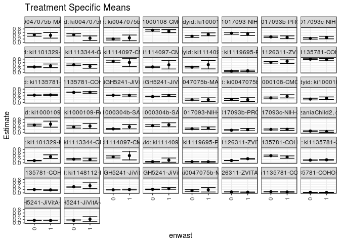

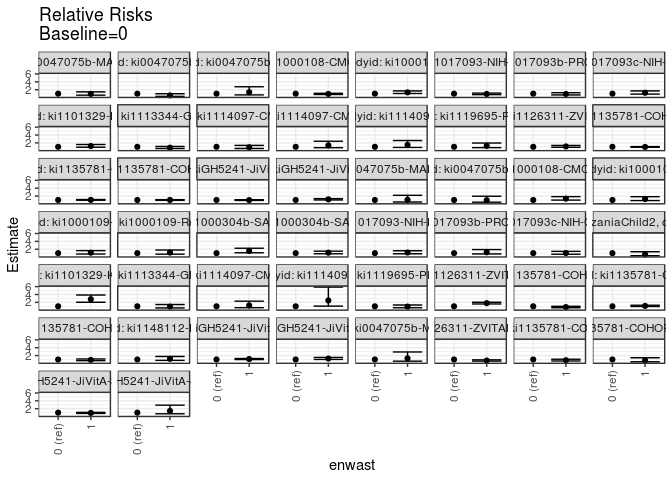

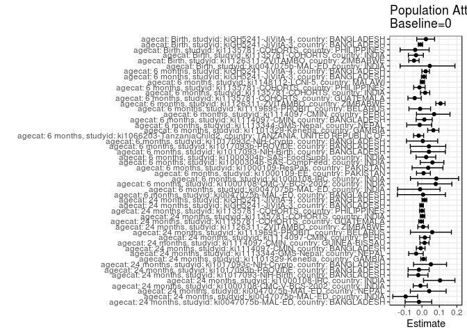

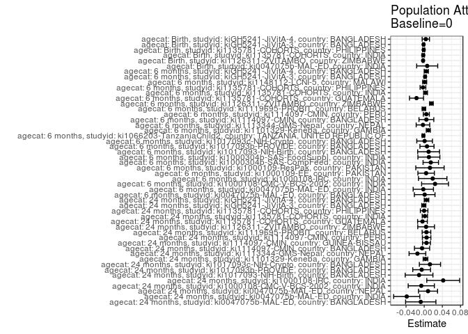

## Results Table

### Parameter: TSM

| agecat | studyid | country | intervention_level | baseline_level | estimate | ci_lower | ci_upper |
| --- | --- | --- | --- | --- | --- | --- | --- |
| Birth | ki0047075b-MAL-ED | INDIA | 0 | NA | 0.1411765 | 0.0887043 | 0.1936486 |
| Birth | ki0047075b-MAL-ED | INDIA | 1 | NA | 0.1818182 | 0.0498993 | 0.3137371 |
| Birth | ki1126311-ZVITAMBO | ZIMBABWE | 0 | NA | 0.0554266 | 0.0511230 | 0.0597303 |
| Birth | ki1126311-ZVITAMBO | ZIMBABWE | 1 | NA | 0.0406698 | 0.0324026 | 0.0489371 |
| Birth | ki1135781-COHORTS | INDIA | 0 | NA | 0.0638890 | 0.0571785 | 0.0705995 |
| Birth | ki1135781-COHORTS | INDIA | 1 | NA | 0.0520261 | 0.0391315 | 0.0649207 |
| Birth | ki1135781-COHORTS | PHILIPPINES | 0 | NA | 0.0306967 | 0.0238605 | 0.0375328 |
| Birth | ki1135781-COHORTS | PHILIPPINES | 1 | NA | 0.0236356 | 0.0097584 | 0.0375129 |
| Birth | kiGH5241-JiVitA-3 | BANGLADESH | 0 | NA | 0.1582454 | 0.1516324 | 0.1648585 |
| Birth | kiGH5241-JiVitA-3 | BANGLADESH | 1 | NA | 0.1469048 | 0.1274747 | 0.1663348 |
| Birth | kiGH5241-JiVitA-4 | BANGLADESH | 0 | NA | 0.1545595 | 0.1236384 | 0.1854806 |
| Birth | kiGH5241-JiVitA-4 | BANGLADESH | 1 | NA | 0.2222222 | 0.0728779 | 0.3715666 |
| 6 months | ki0047075b-MAL-ED | BANGLADESH | 0 | NA | 0.1648936 | 0.1117327 | 0.2180545 |
| 6 months | ki0047075b-MAL-ED | BANGLADESH | 1 | NA | 0.1707317 | 0.0553037 | 0.2861597 |
| 6 months | ki0047075b-MAL-ED | INDIA | 0 | NA | 0.1865285 | 0.1314544 | 0.2416026 |
| 6 months | ki0047075b-MAL-ED | INDIA | 1 | NA | 0.1750000 | 0.0569956 | 0.2930044 |
| 6 months | ki1000108-CMC-V-BCS-2002 | INDIA | 0 | NA | 0.2791255 | 0.2252606 | 0.3329904 |
| 6 months | ki1000108-CMC-V-BCS-2002 | INDIA | 1 | NA | 0.3739357 | 0.2768889 | 0.4709825 |
| 6 months | ki1000108-IRC | INDIA | 0 | NA | 0.2086560 | 0.1586317 | 0.2586803 |
| 6 months | ki1000108-IRC | INDIA | 1 | NA | 0.2608395 | 0.1833290 | 0.3383500 |
| 6 months | ki1000109-EE | PAKISTAN | 0 | NA | 0.4528141 | 0.3957697 | 0.5098586 |
| 6 months | ki1000109-EE | PAKISTAN | 1 | NA | 0.5095699 | 0.3298405 | 0.6892994 |
| 6 months | ki1000109-ResPak | PAKISTAN | 0 | NA | 0.3412803 | 0.2724519 | 0.4101086 |
| 6 months | ki1000109-ResPak | PAKISTAN | 1 | NA | 0.3938604 | 0.2413788 | 0.5463420 |
| 6 months | ki1000304b-SAS-CompFeed | INDIA | 0 | NA | 0.2262435 | 0.2027995 | 0.2496874 |
| 6 months | ki1000304b-SAS-CompFeed | INDIA | 1 | NA | 0.3552234 | 0.2280616 | 0.4823852 |
| 6 months | ki1000304b-SAS-FoodSuppl | INDIA | 0 | NA | 0.4186088 | 0.3635993 | 0.4736183 |
| 6 months | ki1000304b-SAS-FoodSuppl | INDIA | 1 | NA | 0.4706530 | 0.3504006 | 0.5909054 |
| 6 months | ki1017093-NIH-Birth | BANGLADESH | 0 | NA | 0.2334688 | 0.1901521 | 0.2767855 |
| 6 months | ki1017093-NIH-Birth | BANGLADESH | 1 | NA | 0.2714445 | 0.1975411 | 0.3453478 |

[output cut: 70 more lines]

### Parameter: E(Y)

| agecat | studyid | country | intervention_level | baseline_level | estimate | ci_lower | ci_upper |
| --- | --- | --- | --- | --- | --- | --- | --- |
| Birth | ki0047075b-MAL-ED | INDIA | NA | NA | 0.1477833 | 0.0988437 | 0.1967228 |
| Birth | ki1126311-ZVITAMBO | ZIMBABWE | NA | NA | 0.0530095 | 0.0491714 | 0.0568475 |
| Birth | ki1135781-COHORTS | INDIA | NA | NA | 0.0617878 | 0.0558091 | 0.0677665 |
| Birth | ki1135781-COHORTS | PHILIPPINES | NA | NA | 0.0295533 | 0.0233992 | 0.0357074 |
| Birth | kiGH5241-JiVitA-3 | BANGLADESH | NA | NA | 0.1568752 | 0.1505743 | 0.1631761 |
| Birth | kiGH5241-JiVitA-4 | BANGLADESH | NA | NA | 0.1581259 | 0.1278797 | 0.1883722 |
| 6 months | ki0047075b-MAL-ED | BANGLADESH | NA | NA | 0.1659389 | 0.1176493 | 0.2142285 |
| 6 months | ki0047075b-MAL-ED | INDIA | NA | NA | 0.1845494 | 0.1346311 | 0.2344676 |
| 6 months | ki1000108-CMC-V-BCS-2002 | INDIA | NA | NA | 0.3030303 | 0.2556886 | 0.3503720 |
| 6 months | ki1000108-IRC | INDIA | NA | NA | 0.2273902 | 0.1855763 | 0.2692041 |
| 6 months | ki1000109-EE | PAKISTAN | NA | NA | 0.4570552 | 0.4028965 | 0.5112140 |
| 6 months | ki1000109-ResPak | PAKISTAN | NA | NA | 0.3539823 | 0.2914982 | 0.4164664 |
| 6 months | ki1000304b-SAS-CompFeed | INDIA | NA | NA | 0.2407255 | 0.2138448 | 0.2676061 |
| 6 months | ki1000304b-SAS-FoodSuppl | INDIA | NA | NA | 0.4289474 | 0.3791199 | 0.4787748 |
| 6 months | ki1017093-NIH-Birth | BANGLADESH | NA | NA | 0.2431907 | 0.2060665 | 0.2803148 |
| 6 months | ki1017093b-PROVIDE | BANGLADESH | NA | NA | 0.1527778 | 0.1233713 | 0.1821843 |
| 6 months | ki1017093c-NIH-Crypto | BANGLADESH | NA | NA | 0.1930836 | 0.1636957 | 0.2224715 |
| 6 months | ki1066203-TanzaniaChild2 | TANZANIA, UNITED REPUBLIC OF | NA | NA | 0.0960396 | 0.0831873 | 0.1088919 |
| 6 months | ki1101329-Keneba | GAMBIA | NA | NA | 0.1385948 | 0.1237352 | 0.1534544 |
| 6 months | ki1113344-GMS-Nepal | NEPAL | NA | NA | 0.2085561 | 0.1749069 | 0.2422054 |
| 6 months | ki1114097-CMIN | BANGLADESH | NA | NA | 0.3534483 | 0.2918020 | 0.4150945 |
| 6 months | ki1114097-CMIN | PERU | NA | NA | 0.0675039 | 0.0480051 | 0.0870027 |
| 6 months | ki1119695-PROBIT | BELARUS | NA | NA | 0.0625873 | 0.0488338 | 0.0763408 |
| 6 months | ki1126311-ZVITAMBO | ZIMBABWE | NA | NA | 0.1497769 | 0.1418798 | 0.1576740 |
| 6 months | ki1135781-COHORTS | GUATEMALA | NA | NA | 0.4062153 | 0.3741290 | 0.4383016 |
| 6 months | ki1135781-COHORTS | INDIA | NA | NA | 0.1611862 | 0.1522521 | 0.1701204 |
| 6 months | ki1135781-COHORTS | PHILIPPINES | NA | NA | 0.1932125 | 0.1780130 | 0.2084119 |
| 6 months | ki1148112-LCNI-5 | MALAWI | NA | NA | 0.3682956 | 0.3356382 | 0.4009530 |
| 6 months | kiGH5241-JiVitA-3 | BANGLADESH | NA | NA | 0.1812307 | 0.1736272 | 0.1888342 |
| 6 months | kiGH5241-JiVitA-4 | BANGLADESH | NA | NA | 0.2156463 | 0.2019366 | 0.2293559 |
| 24 months | ki0047075b-MAL-ED | BANGLADESH | NA | NA | 0.4378109 | 0.3690538 | 0.5065681 |
| 24 months | ki0047075b-MAL-ED | INDIA | NA | NA | 0.4107143 | 0.3461446 | 0.4752839 |
| 24 months | ki0047075b-MAL-ED | NEPAL | NA | NA | 0.2044444 | 0.1516307 | 0.2572582 |
| 24 months | ki1000108-CMC-V-BCS-2002 | INDIA | NA | NA | 0.7178082 | 0.6715729 | 0.7640435 |
| 24 months | ki1000108-IRC | INDIA | NA | NA | 0.4046392 | 0.3557383 | 0.4535401 |
| 24 months | ki1017093-NIH-Birth | BANGLADESH | NA | NA | 0.5330073 | 0.4845968 | 0.5814178 |
| 24 months | ki1017093b-PROVIDE | BANGLADESH | NA | NA | 0.3251318 | 0.2866094 | 0.3636542 |
| 24 months | ki1017093c-NIH-Crypto | BANGLADESH | NA | NA | 0.2480000 | 0.2101093 | 0.2858907 |
| 24 months | ki1101329-Keneba | GAMBIA | NA | NA | 0.3333333 | 0.3110228 | 0.3556439 |
| 24 months | ki1113344-GMS-Nepal | NEPAL | NA | NA | 0.4446680 | 0.4009358 | 0.4884002 |
| 24 months | ki1114097-CMIN | BANGLADESH | NA | NA | 0.6681034 | 0.6073788 | 0.7288281 |
| 24 months | ki1114097-CMIN | GUINEA-BISSAU | NA | NA | 0.3357664 | 0.2961903 | 0.3753426 |
| 24 months | ki1114097-CMIN | PERU | NA | NA | 0.3193473 | 0.2751780 | 0.3635166 |
| 24 months | ki1119695-PROBIT | BELARUS | NA | NA | 0.0850694 | 0.0559313 | 0.1142076 |
| 24 months | ki1126311-ZVITAMBO | ZIMBABWE | NA | NA | 0.6140351 | 0.5662077 | 0.6618625 |
| 24 months | ki1135781-COHORTS | GUATEMALA | NA | NA | 0.7920311 | 0.7672214 | 0.8168408 |
| 24 months | ki1135781-COHORTS | INDIA | NA | NA | 0.4466575 | 0.4329730 | 0.4603419 |
| 24 months | ki1135781-COHORTS | PHILIPPINES | NA | NA | 0.6075841 | 0.5878253 | 0.6273430 |
| 24 months | kiGH5241-JiVitA-3 | BANGLADESH | NA | NA | 0.4380268 | 0.4238665 | 0.4521871 |
| 24 months | kiGH5241-JiVitA-4 | BANGLADESH | NA | NA | 0.3640788 | 0.3464603 | 0.3816973 |

### Parameter: RR

| agecat | studyid | country | intervention_level | baseline_level | estimate | ci_lower | ci_upper |
| --- | --- | --- | --- | --- | --- | --- | --- |
| Birth | ki0047075b-MAL-ED | INDIA | 0 | 0 | 1.0000000 | 1.0000000 | 1.0000000 |
| Birth | ki0047075b-MAL-ED | INDIA | 1 | 0 | 1.2878788 | 0.5699441 | 2.9101656 |
| Birth | ki1126311-ZVITAMBO | ZIMBABWE | 0 | 0 | 1.0000000 | 1.0000000 | 1.0000000 |
| Birth | ki1126311-ZVITAMBO | ZIMBABWE | 1 | 0 | 0.7337593 | 0.5902915 | 0.9120965 |
| Birth | ki1135781-COHORTS | INDIA | 0 | 0 | 1.0000000 | 1.0000000 | 1.0000000 |
| Birth | ki1135781-COHORTS | INDIA | 1 | 0 | 0.8143204 | 0.6223933 | 1.0654321 |
| Birth | ki1135781-COHORTS | PHILIPPINES | 0 | 0 | 1.0000000 | 1.0000000 | 1.0000000 |
| Birth | ki1135781-COHORTS | PHILIPPINES | 1 | 0 | 0.7699742 | 0.4110085 | 1.4424524 |
| Birth | kiGH5241-JiVitA-3 | BANGLADESH | 0 | 0 | 1.0000000 | 1.0000000 | 1.0000000 |
| Birth | kiGH5241-JiVitA-3 | BANGLADESH | 1 | 0 | 0.9283348 | 0.8086021 | 1.0657969 |
| Birth | kiGH5241-JiVitA-4 | BANGLADESH | 0 | 0 | 1.0000000 | 1.0000000 | 1.0000000 |
| Birth | kiGH5241-JiVitA-4 | BANGLADESH | 1 | 0 | 1.4377778 | 0.7114932 | 2.9054456 |
| 6 months | ki0047075b-MAL-ED | BANGLADESH | 0 | 0 | 1.0000000 | 1.0000000 | 1.0000000 |
| 6 months | ki0047075b-MAL-ED | BANGLADESH | 1 | 0 | 1.0354052 | 0.4895738 | 2.1897902 |
| 6 months | ki0047075b-MAL-ED | INDIA | 0 | 0 | 1.0000000 | 1.0000000 | 1.0000000 |
| 6 months | ki0047075b-MAL-ED | INDIA | 1 | 0 | 0.9381944 | 0.4493659 | 1.9587797 |
| 6 months | ki1000108-CMC-V-BCS-2002 | INDIA | 0 | 0 | 1.0000000 | 1.0000000 | 1.0000000 |
| 6 months | ki1000108-CMC-V-BCS-2002 | INDIA | 1 | 0 | 1.3396687 | 0.9703346 | 1.8495810 |
| 6 months | ki1000108-IRC | INDIA | 0 | 0 | 1.0000000 | 1.0000000 | 1.0000000 |
| 6 months | ki1000108-IRC | INDIA | 1 | 0 | 1.2500933 | 0.8522262 | 1.8337073 |
| 6 months | ki1000109-EE | PAKISTAN | 0 | 0 | 1.0000000 | 1.0000000 | 1.0000000 |
| 6 months | ki1000109-EE | PAKISTAN | 1 | 0 | 1.1253401 | 0.7737255 | 1.6367438 |
| 6 months | ki1000109-ResPak | PAKISTAN | 0 | 0 | 1.0000000 | 1.0000000 | 1.0000000 |
| 6 months | ki1000109-ResPak | PAKISTAN | 1 | 0 | 1.1540672 | 0.7446450 | 1.7885990 |
| 6 months | ki1000304b-SAS-CompFeed | INDIA | 0 | 0 | 1.0000000 | 1.0000000 | 1.0000000 |
| 6 months | ki1000304b-SAS-CompFeed | INDIA | 1 | 0 | 1.5700937 | 1.0949637 | 2.2513936 |
| 6 months | ki1000304b-SAS-FoodSuppl | INDIA | 0 | 0 | 1.0000000 | 1.0000000 | 1.0000000 |
| 6 months | ki1000304b-SAS-FoodSuppl | INDIA | 1 | 0 | 1.1243266 | 0.8426464 | 1.5001668 |
| 6 months | ki1017093-NIH-Birth | BANGLADESH | 0 | 0 | 1.0000000 | 1.0000000 | 1.0000000 |
| 6 months | ki1017093-NIH-Birth | BANGLADESH | 1 | 0 | 1.1626585 | 0.8363094 | 1.6163575 |

[output cut: 70 more lines]

### Parameter: PAR

| agecat | studyid | country | intervention_level | baseline_level | estimate | ci_lower | ci_upper |
| --- | --- | --- | --- | --- | --- | --- | --- |
| Birth | ki0047075b-MAL-ED | INDIA | 0 | NA | 0.0066068 | -0.0165648 | 0.0297784 |
| Birth | ki1126311-ZVITAMBO | ZIMBABWE | 0 | NA | -0.0024172 | -0.0039953 | -0.0008390 |
| Birth | ki1135781-COHORTS | INDIA | 0 | NA | -0.0021011 | -0.0047581 | 0.0005558 |
| Birth | ki1135781-COHORTS | PHILIPPINES | 0 | NA | -0.0011434 | -0.0036075 | 0.0013207 |
| Birth | kiGH5241-JiVitA-3 | BANGLADESH | 0 | NA | -0.0013702 | -0.0033197 | 0.0005792 |
| Birth | kiGH5241-JiVitA-4 | BANGLADESH | 0 | NA | 0.0035664 | -0.0045137 | 0.0116465 |
| 6 months | ki0047075b-MAL-ED | BANGLADESH | 0 | NA | 0.0010452 | -0.0217092 | 0.0237997 |
| 6 months | ki0047075b-MAL-ED | INDIA | 0 | NA | -0.0019791 | -0.0243421 | 0.0203838 |
| 6 months | ki1000108-CMC-V-BCS-2002 | INDIA | 0 | NA | 0.0239048 | -0.0056857 | 0.0534953 |
| 6 months | ki1000108-IRC | INDIA | 0 | NA | 0.0187342 | -0.0126219 | 0.0500903 |
| 6 months | ki1000109-EE | PAKISTAN | 0 | NA | 0.0042411 | -0.0139054 | 0.0223875 |
| 6 months | ki1000109-ResPak | PAKISTAN | 0 | NA | 0.0127020 | -0.0185326 | 0.0439366 |
| 6 months | ki1000304b-SAS-CompFeed | INDIA | 0 | NA | 0.0144820 | -0.0025564 | 0.0315204 |
| 6 months | ki1000304b-SAS-FoodSuppl | INDIA | 0 | NA | 0.0103386 | -0.0138410 | 0.0345181 |
| 6 months | ki1017093-NIH-Birth | BANGLADESH | 0 | NA | 0.0097219 | -0.0143573 | 0.0338011 |
| 6 months | ki1017093b-PROVIDE | BANGLADESH | 0 | NA | 0.0061289 | -0.0093875 | 0.0216452 |
| 6 months | ki1017093c-NIH-Crypto | BANGLADESH | 0 | NA | 0.0009203 | -0.0163293 | 0.0181698 |
| 6 months | ki1066203-TanzaniaChild2 | TANZANIA, UNITED REPUBLIC OF | 0 | NA | -0.0018036 | -0.0045870 | 0.0009797 |
| 6 months | ki1101329-Keneba | GAMBIA | 0 | NA | 0.0090514 | 0.0045602 | 0.0135426 |
| 6 months | ki1113344-GMS-Nepal | NEPAL | 0 | NA | -0.0027567 | -0.0176603 | 0.0121469 |
| 6 months | ki1114097-CMIN | BANGLADESH | 0 | NA | 0.0048244 | -0.0114980 | 0.0211468 |
| 6 months | ki1114097-CMIN | PERU | 0 | NA | 0.0046940 | -0.0018986 | 0.0112867 |
| 6 months | ki1119695-PROBIT | BELARUS | 0 | NA | -0.0006722 | -0.0045608 | 0.0032165 |
| 6 months | ki1126311-ZVITAMBO | ZIMBABWE | 0 | NA | 0.0159096 | 0.0119095 | 0.0199097 |
| 6 months | ki1135781-COHORTS | GUATEMALA | 0 | NA | -0.0169374 | -0.0323705 | -0.0015043 |
| 6 months | ki1135781-COHORTS | INDIA | 0 | NA | 0.0029413 | -0.0013180 | 0.0072007 |
| 6 months | ki1135781-COHORTS | PHILIPPINES | 0 | NA | -0.0027394 | -0.0090351 | 0.0035563 |
| 6 months | ki1148112-LCNI-5 | MALAWI | 0 | NA | 0.0010229 | -0.0034161 | 0.0054618 |
| 6 months | kiGH5241-JiVitA-3 | BANGLADESH | 0 | NA | 0.0019415 | -0.0005285 | 0.0044115 |
| 6 months | kiGH5241-JiVitA-4 | BANGLADESH | 0 | NA | 0.0045893 | -0.0000034 | 0.0091819 |
| 24 months | ki0047075b-MAL-ED | BANGLADESH | 0 | NA | -0.0076022 | -0.0410070 | 0.0258026 |
| 24 months | ki0047075b-MAL-ED | INDIA | 0 | NA | -0.0384585 | -0.0672639 | -0.0096531 |
| 24 months | ki0047075b-MAL-ED | NEPAL | 0 | NA | 0.0084645 | -0.0125139 | 0.0294430 |
| 24 months | ki1000108-CMC-V-BCS-2002 | INDIA | 0 | NA | -0.0064239 | -0.0352779 | 0.0224302 |
| 24 months | ki1000108-IRC | INDIA | 0 | NA | 0.0418515 | 0.0056725 | 0.0780306 |
| 24 months | ki1017093-NIH-Birth | BANGLADESH | 0 | NA | -0.0113128 | -0.0418575 | 0.0192319 |
| 24 months | ki1017093b-PROVIDE | BANGLADESH | 0 | NA | -0.0056385 | -0.0251967 | 0.0139198 |
| 24 months | ki1017093c-NIH-Crypto | BANGLADESH | 0 | NA | 0.0126681 | -0.0106959 | 0.0360320 |
| 24 months | ki1101329-Keneba | GAMBIA | 0 | NA | 0.0028419 | -0.0022562 | 0.0079399 |
| 24 months | ki1113344-GMS-Nepal | NEPAL | 0 | NA | -0.0149056 | -0.0333078 | 0.0034966 |
| 24 months | ki1114097-CMIN | BANGLADESH | 0 | NA | -0.0047076 | -0.0214330 | 0.0120178 |
| 24 months | ki1114097-CMIN | GUINEA-BISSAU | 0 | NA | 0.0050278 | -0.0037209 | 0.0137765 |
| 24 months | ki1114097-CMIN | PERU | 0 | NA | 0.0053377 | -0.0040226 | 0.0146979 |
| 24 months | ki1119695-PROBIT | BELARUS | 0 | NA | 0.0049832 | -0.0044954 | 0.0144618 |
| 24 months | ki1126311-ZVITAMBO | ZIMBABWE | 0 | NA | 0.0042532 | -0.0141997 | 0.0227061 |
| 24 months | ki1135781-COHORTS | GUATEMALA | 0 | NA | -0.0038294 | -0.0145189 | 0.0068600 |
| 24 months | ki1135781-COHORTS | INDIA | 0 | NA | 0.0014587 | -0.0043875 | 0.0073050 |
| 24 months | ki1135781-COHORTS | PHILIPPINES | 0 | NA | -0.0001450 | -0.0084541 | 0.0081641 |
| 24 months | kiGH5241-JiVitA-3 | BANGLADESH | 0 | NA | -0.0009188 | -0.0054339 | 0.0035963 |
| 24 months | kiGH5241-JiVitA-4 | BANGLADESH | 0 | NA | 0.0051243 | 0.0001641 | 0.0100845 |

### Parameter: PAF

| agecat | studyid | country | intervention_level | baseline_level | estimate | ci_lower | ci_upper |
| --- | --- | --- | --- | --- | --- | --- | --- |
| Birth | ki0047075b-MAL-ED | INDIA | 0 | NA | 0.0447059 | -0.1251384 | 0.1889115 |
| Birth | ki1126311-ZVITAMBO | ZIMBABWE | 0 | NA | -0.0455987 | -0.0756212 | -0.0164142 |
| Birth | ki1135781-COHORTS | INDIA | 0 | NA | -0.0340056 | -0.0778036 | 0.0080126 |
| Birth | ki1135781-COHORTS | PHILIPPINES | 0 | NA | -0.0386890 | -0.1251244 | 0.0411061 |
| Birth | kiGH5241-JiVitA-3 | BANGLADESH | 0 | NA | -0.0087346 | -0.0212398 | 0.0036175 |
| Birth | kiGH5241-JiVitA-4 | BANGLADESH | 0 | NA | 0.0225542 | -0.0298726 | 0.0723122 |
| 6 months | ki0047075b-MAL-ED | BANGLADESH | 0 | NA | 0.0062990 | -0.1407298 | 0.1343772 |
| 6 months | ki0047075b-MAL-ED | INDIA | 0 | NA | -0.0107242 | -0.1394422 | 0.1034531 |
| 6 months | ki1000108-CMC-V-BCS-2002 | INDIA | 0 | NA | 0.0788859 | -0.0239375 | 0.1713838 |
| 6 months | ki1000108-IRC | INDIA | 0 | NA | 0.0823879 | -0.0658358 | 0.2099983 |
| 6 months | ki1000109-EE | PAKISTAN | 0 | NA | 0.0092791 | -0.0312411 | 0.0482072 |
| 6 months | ki1000109-ResPak | PAKISTAN | 0 | NA | 0.0358832 | -0.0565142 | 0.1202000 |
| 6 months | ki1000304b-SAS-CompFeed | INDIA | 0 | NA | 0.0601599 | -0.0099636 | 0.1254146 |
| 6 months | ki1000304b-SAS-FoodSuppl | INDIA | 0 | NA | 0.0241022 | -0.0339498 | 0.0788948 |
| 6 months | ki1017093-NIH-Birth | BANGLADESH | 0 | NA | 0.0399764 | -0.0642229 | 0.1339735 |
| 6 months | ki1017093b-PROVIDE | BANGLADESH | 0 | NA | 0.0401163 | -0.0668696 | 0.1363736 |
| 6 months | ki1017093c-NIH-Crypto | BANGLADESH | 0 | NA | 0.0047661 | -0.0887139 | 0.0902197 |
| 6 months | ki1066203-TanzaniaChild2 | TANZANIA, UNITED REPUBLIC OF | 0 | NA | -0.0187801 | -0.0480893 | 0.0097095 |
| 6 months | ki1101329-Keneba | GAMBIA | 0 | NA | 0.0653081 | 0.0328784 | 0.0966504 |
| 6 months | ki1113344-GMS-Nepal | NEPAL | 0 | NA | -0.0132180 | -0.0872697 | 0.0557901 |
| 6 months | ki1114097-CMIN | BANGLADESH | 0 | NA | 0.0136496 | -0.0336341 | 0.0587702 |
| 6 months | ki1114097-CMIN | PERU | 0 | NA | 0.0695368 | -0.0314343 | 0.1606235 |
| 6 months | ki1119695-PROBIT | BELARUS | 0 | NA | -0.0107398 | -0.0745684 | 0.0492974 |
| 6 months | ki1126311-ZVITAMBO | ZIMBABWE | 0 | NA | 0.1062221 | 0.0795035 | 0.1321652 |
| 6 months | ki1135781-COHORTS | GUATEMALA | 0 | NA | -0.0416956 | -0.0804482 | -0.0043330 |
| 6 months | ki1135781-COHORTS | INDIA | 0 | NA | 0.0182479 | -0.0085264 | 0.0443113 |
| 6 months | ki1135781-COHORTS | PHILIPPINES | 0 | NA | -0.0141782 | -0.0472777 | 0.0178752 |
| 6 months | ki1148112-LCNI-5 | MALAWI | 0 | NA | 0.0027773 | -0.0093645 | 0.0147730 |
| 6 months | kiGH5241-JiVitA-3 | BANGLADESH | 0 | NA | 0.0107130 | -0.0029708 | 0.0242102 |
| 6 months | kiGH5241-JiVitA-4 | BANGLADESH | 0 | NA | 0.0212814 | -0.0003015 | 0.0423986 |
| 24 months | ki0047075b-MAL-ED | BANGLADESH | 0 | NA | -0.0173641 | -0.0966216 | 0.0561652 |
| 24 months | ki0047075b-MAL-ED | INDIA | 0 | NA | -0.0936381 | -0.1669206 | -0.0249577 |
| 24 months | ki0047075b-MAL-ED | NEPAL | 0 | NA | 0.0414027 | -0.0665873 | 0.1384589 |
| 24 months | ki1000108-CMC-V-BCS-2002 | INDIA | 0 | NA | -0.0089493 | -0.0499866 | 0.0304842 |
| 24 months | ki1000108-IRC | INDIA | 0 | NA | 0.1034293 | 0.0091894 | 0.1887057 |
| 24 months | ki1017093-NIH-Birth | BANGLADESH | 0 | NA | -0.0212245 | -0.0802193 | 0.0345484 |
| 24 months | ki1017093b-PROVIDE | BANGLADESH | 0 | NA | -0.0173421 | -0.0793067 | 0.0410651 |
| 24 months | ki1017093c-NIH-Crypto | BANGLADESH | 0 | NA | 0.0510810 | -0.0480062 | 0.1407996 |
| 24 months | ki1101329-Keneba | GAMBIA | 0 | NA | 0.0085257 | -0.0068879 | 0.0237032 |
| 24 months | ki1113344-GMS-Nepal | NEPAL | 0 | NA | -0.0335208 | -0.0758492 | 0.0071423 |
| 24 months | ki1114097-CMIN | BANGLADESH | 0 | NA | -0.0070462 | -0.0324198 | 0.0177037 |
| 24 months | ki1114097-CMIN | GUINEA-BISSAU | 0 | NA | 0.0149741 | -0.0114270 | 0.0406861 |
| 24 months | ki1114097-CMIN | PERU | 0 | NA | 0.0167143 | -0.0130303 | 0.0455855 |
| 24 months | ki1119695-PROBIT | BELARUS | 0 | NA | 0.0585780 | -0.0659702 | 0.1685740 |
| 24 months | ki1126311-ZVITAMBO | ZIMBABWE | 0 | NA | 0.0069266 | -0.0235960 | 0.0365390 |
| 24 months | ki1135781-COHORTS | GUATEMALA | 0 | NA | -0.0048350 | -0.0184277 | 0.0085763 |
| 24 months | ki1135781-COHORTS | INDIA | 0 | NA | 0.0032659 | -0.0099102 | 0.0162702 |
| 24 months | ki1135781-COHORTS | PHILIPPINES | 0 | NA | -0.0002386 | -0.0140082 | 0.0133440 |
| 24 months | kiGH5241-JiVitA-3 | BANGLADESH | 0 | NA | -0.0020977 | -0.0124595 | 0.0081581 |
| 24 months | kiGH5241-JiVitA-4 | BANGLADESH | 0 | NA | 0.0140747 | 0.0003303 | 0.0276301 |